# hometown-outcomes-2

Michael

2019-02-22

## Setup

```r
# Libraries
library(sf)
library(tidycensus)
library(tmap)
library(tmaptools)
library(shinyjs)
library(tidyverse)

# Parameters

  # Census API Key
census_key <- "891e70ea96814a52b3992d4f85fd4fb500721349"

  # Answer filepath from part 1 of this challenge
file_answers <- "C:\\Users\\Michael Spencer\\Desktop\\ENGR 150 DATA\\c01\\ho-1\\answers.rds"

  # County level outcomes filepath
county_outcomes_ez_file <- "C:\\Users\\Michael Spencer\\Desktop\\ENGR 150 DATA\\c01\\county_outcomes_ez.csv"

  # Census tract level outcomes filepath
ct_outcomes_ez_file <- "C:\\Users\\Michael Spencer\\Desktop\\ENGR 150 DATA\\c01\\ct_outcomes_ez.csv"

  # Albers projection for 48 contiguous US states
US_ALBERS <- "+proj=aea +lat_1=29.5 +lat_2=45.5 +lat_0=37.5 +lon_0=-96 +x_0=0 +y_0=0 +datum=WGS84 +no_defs"

  # Alaska State FIP
alaska_state_fip <- 2

  # Hawaii Stte FIP
hawaii_state_fip <- 15

  # PR State FIP
pr_state_fip <- 72

  # Atlas Colors
atlas_colors <- c("#9a212f", "#9a212f", "#ffffc9", "#31677e", "#31677e")

  # Atlas NA Color
atlas_na_color <- "#d1d1d0"

  # Tidycensus dummy variable
tidycensus_dummy <- "B01001_001"

  # Set formatting for tmap
my_format <- scales::percent_format(accuracy = 5)

SAVE_ANSWERS = FALSE
#===============================================================================

# Files

  # File with shapefile and outcome data
if (str_length(file_answers) > 0) {
  joined_data <- read_rds(file_answers)
}

#--- uncomment lines below once you input proper filepaths above

  # Set census API key for tidycensus use
census_api_key(census_key)

  # Read in county level outcomes
county_outcomes_ez <- read_csv(county_outcomes_ez_file)

  # Read in census tract level outcomes
ct_outcomes_ez <- read_csv(ct_outcomes_ez_file)

#---
```

## Helper Functions

```r
transform_geo <- function(geo_bounds) {

  geo_bounds %>%
    st_transform(US_ALBERS) %>%
    mutate(
      state = as.integer(str_extract(GEOID, "^\\d{2}")),
      county = as.integer(str_extract(GEOID, "(?<=\\d{2})\\d{3}")),
      tract = as.integer(str_extract(GEOID, "\\d{6}$"))
    ) %>%
    filter(
      state != alaska_state_fip,
      state != hawaii_state_fip,
      state != pr_state_fip
    )
}
```

#===============================================================================

## Introduction

This challenge is based off of work and data from the Opportunity Atlas, a project headed by Raj Chetty et. al. The work has sparked policy considerations regarding the possibility of moving people into affordable, high-mobility neighborhoods in hopes it would lead them to better social outcomes. You can find links to the the original paper, interactive map, data, and a NYT article below. Check them out to familiarize yourself with the info!

- Paper: https://opportunityinsights.org/wp-content/uploads/2018/10/atlas_paper.pdf
- Interactive Map: https://www.opportunityatlas.org/
- Data: https://opportunityinsights.org/data/?geographic_level=0&topic=0&paper_id=1652#resource-listing
- Press Articles: https://opportunityinsights.org/press-paper/the-opportunity-atlas-mapping-the-childhood-roots-of-social-mobility/

The goal of this challenge is to explore some key mobility outcomes for an area of your choosing, such as income, incarceration, and teen pregnancy. For the sake of simplicity, you won’t be able to explore areas outside of the continental United States, nor can you explore Washington D.C. as it’s special designation makes it difficult with the tools we have.

**Disclaimer:** The challenge below may appear a bit wordy, but it is meant to be highly guided and used as a relatively painless learning experience.

#===============================================================================

## Downloading Mobility Data & Tidycensus Setup

#### Reading in data

To begin, we must read in the data. For simplicity, the bulk of the processing has done for you. Go to the box folder for this challenge’s data - [https://stanford.box.com/s/uafg88ya77as4zuf02bq6ehjif5yvbys] - and download the data to someplace on your computer that is not your personal repo. Then locate the files, and copy their filepaths to the corresponsding paramters above. Once you’ve done this, uncomment and run the lines above in **Setup** that read in the csv files.

#### Your census API key

In this challenge, we’ll use the tidycensus package, developed by Kyle Walker. You can read up on it here - https://walkerke.github.io/tidycensus/articles/basic-usage.html. The package allows quick and easy access to census data by giving you a series of functions which take basic information such as the geography you wish to gather data for, the state, location, and several other parameters.

To do this, you must create a census API key. You can easily do this using the following link - http://api.census.gov/data/key_signup.html. Once you have your key, copy and paste it into the `census_key` parameter above. Uncomment the line “census_api_key” line and run it. This will install the key onto your computer for future use.

#===============================================================================

## Mapping Data

#### Mapping general data

Now that we have all of our data joined and fit for mapping (per part 1 of this challenge), we’ll learn about the tmap library of functions, which allow for plotting of both static and intractive maps fairly easily. You can browse through some of the basic functionality at this link - https://cran.r-project.org/web/packages/tmap/vignettes/tmap-getstarted.html - though the documentation isn’t the best. That said, below I’ll step through using some of the functions I’ve found most helpful in creating a fun and exciting map!

Review some of the basic methods and layering techniques here.

```r
?tmap
```

```
## starting httpd help server ... done
```

- `tm_basemap()` to lay a basemap
- `tm_shape()` to define an object we want to look into for relevant mapping data such as geometries and outcome variables
- `tm_polygons()` which serves to fill in our maps with the desired data, specifications, style, etc.
- `tm_layout()` to help format out map (though it isn’t perfect)
- `tmap_mode()` to toggle between static and interactive maps

I recommend looking at the documentation for each of these to familiarize yourself with the various arguments

**q1** To create your first map using the New York data (`joined_data$q3.1` & `joined_data$q3.2`), you only need 4 lines of code. This is the beauty of tmap. They won’t be the prettiest, but we’ll get there.

- Hints
  - The first line should specify a basemap. I recommend using `leaflet::providers$Stamen.TonerLite`, but you can find a fuller list at this link - https://leaflet-extras.github.io/leaflet-providers/preview/.
  - The second line should specify the dataframe that you want to use, which should include the geometry and outcome/mobility variable you want to map.
  - The third line should specify the outcome you want to map. For these maps, let’s map the projected household income percentile of an adult who grew up in a given area as a child and whose parents were in the bottom quartile of income - this has been renamed as `household_income` in our mobility data.
  - The last line will specify that we want to map a static map.

**q1.1** Create a static map of your `joined_data$q3.1` data using the steps above. Check the documentation for each of the above functions if you need assistance. For now, each function should only require one argument. Store it in the variable `q1.1`.

```r
q1.1 <-
  tm_basemap(leaflet::providers$Stamen.TonerLite) +
  tm_shape(joined_data$q3.1) +
  tm_polygons("household_income") +
  tmap_mode("plot")
```

```
## tmap mode set to plotting
```

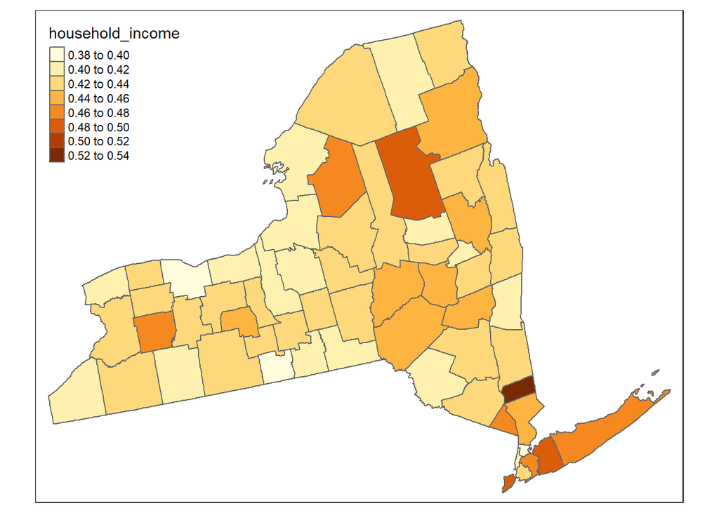

```r
q1.1
```

To change this map into an interactive map, which will also allow us to drag and zoom, all we need to do is toggle between views using `ttm()`. Note that layers and functions in `tmap`, like `ggplot2` are added with a +.

```r
q1.1 +
  ttm()
```

```
## tmap mode set to interactive viewing
```

[interactive chart not shown]

Notice that we can’t see the basemap below. This is because `tm_polygons()` has a dafult `alpha` of 1.

**q1.2** Using the same code that you wrote above in `q1.1` (copy and paste it over), adjust the alpha argument with `tm_polygons()` to make the map more informative. Make sure to make the map interactive with `tmap_mode()`. Store this map as q1.2.

```r
q1.2 <-
  tm_basemap(leaflet::providers$Stamen.TonerLite) +
  tm_shape(joined_data$q3.1) +
  tm_polygons("household_income", alpha = .8) +
  tmap_mode("view")
```

```
## tmap mode set to interactive viewing
```

```r
q1.2
```

[interactive chart not shown]

Much better! Now, in this last step we’ll put the finishing touches on our map. Namely, we’ll adjust the coloring with `breaks`, `style`, `palette`, and `colorNA`, legend formatting (which will only affect the static map legend) using `labels` and `legend.format`, popup formatting using `id` (which is only present in the interactive version), and the overall aesthetic using `tm_layout()` and it’s arguments `frame` and `main.title`.

To aid in several of these things, we’ll use two functions: the first, `color_breaks()`, finds the proper breaks for the 0th, 2.5th, 50th, 97.5th, and 100th percentiles; the second in the `Setup` section above is called `my_format()` and formats the legend.labels in the static map.

I’ve also provided colors as `atlas_colors` and `atlas_na_color` which correspond to the same colors used in the official paper.

```r
# Takes the bounds data, and the outcome you are mapping as a string

color_breaks <- function(bounds, outcome) {

  vals <-
    c(
      quantile(bounds[[outcome]], 0, na.rm = TRUE),
      quantile(bounds[[outcome]], .025, na.rm = TRUE) + .00001,
      median(bounds[[outcome]], na.rm = TRUE),
      quantile(bounds[[outcome]], .975, na.rm = TRUE),
      quantile(bounds[[outcome]], 1, na.rm = TRUE)
    )

  vals

}
```

**q1.3** Starting with the same code as you used in `q1.2` (copy it over), add in the above arguments to produce a static map of the New York State data. Save the static plot into `q1.3` and then use that + `ttm()` to create an interactive version of your map.

- Hints:
  - We want the coloring scheme to be a continuous gradient. To do this, use `style = "cont"`.
  - If you wanted to map a variable in which higher values are considered worse, such as `male_incarceration_rates`, you could reverse the color scale palette by using `rev(atlas_colors)`.
  - To use `my_format()`, pass in the breaks of the legend which are calculated using `color_breaks()`.
  - The popup id’s should be informative and should use the names of each observation ie. the name of the county.
  - Within `tm_layout`, it is best to have no frame.
  - For cleanliness, include the following lines within `tm_layout()`:
    - legend.outside = TRUE, legend.outside.position = “right”

```r
q1.3 <-
  tm_basemap(leaflet::providers$Stamen.TonerLite) +
  tm_shape(joined_data$q3.1) +
  tm_polygons(
    "household_income",
    breaks = color_breaks(joined_data$q3.1, "household_income"),
    style = "cont",
    palette = atlas_colors,
    colorNA = atlas_na_color,
    labels = my_format(color_breaks(joined_data$q3.1, "household_income")),
    legend.format =
      my_format(color_breaks(joined_data$q3.1, "household_income")),
    id = "NAME",
    popup.vars = "household_income",
    alpha = .8
  ) +
  tm_layout(
    frame = FALSE,
    main.title = "Adults mean household income percentile",
    main.title.size = .7,
    legend.outside = TRUE,
    legend.outside.position = "right"
  ) +
  tmap_mode("plot")
```

```
## tmap mode set to plotting
```

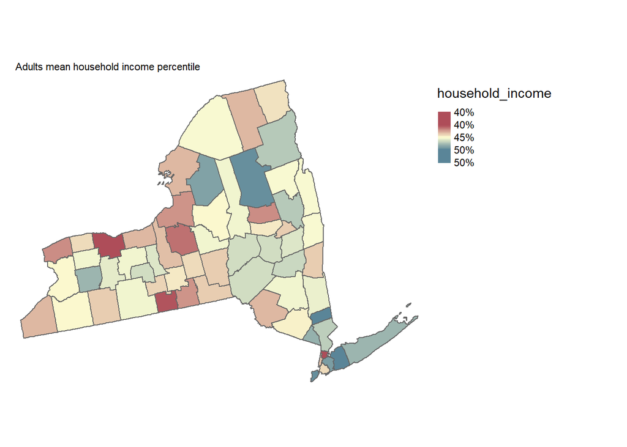

```r
q1.3
```

```r
q1.3 + ttm()
```

```
## tmap mode set to interactive viewing
```

[interactive chart not shown]

Pretty neat right!?

#### Personal mapping

**q2** You may notice that the above code in q1.3 is pretty generalizeable to any set of shapefiles/outcome data we may have, and to any outcome we want to look at. With this in mind, let’s explore some data a bit more relevant to you. Using the chunk below input your home state and county. For those outside the U.S., choose a state and county that is interesting to you. Note that you cannot explore regions outside the U.S., nor Washington D.C. due to its special designation.

```r
my_state <- "California"
my_county <- "Santa Clara"

my_state_bounds <-
  get_acs(
    geography = "county",
    state = my_state,
    geometry = TRUE,
    variables = tidycensus_dummy,
    year = 2010
  ) %>%
  transform_geo() %>%
  left_join(
    county_outcomes_ez,
    by = c("state", "county")
  )
my_county_bounds <-
  get_acs(
    geography = "tract",
    state = my_state,
    county = my_county,
    geometry = TRUE,
    variables = tidycensus_dummy,
    year = 2010
  ) %>%
  transform_geo() %>%
  left_join(
    ct_outcomes_ez,
    by = c("state", "county", "tract")
  )
```

To start mapping this data, you could try retyping the tmap code from scratch or simply use your existing code from `q1.3`. If you choose to re-use the existing code, the only items that should need to be changed are the boundary data passed in, the outcome you wish to map, the main title, and if it is appropriate, reverse the vector of `atlas_colors` passed to `palette`.

Make at least 2 maps for your state and 2 for your county. For each, one should be a static map and the other should be an interactive map for at least a total of 2 static and 2 interactive. Again, this should be fairly simple if you reuse the code from above. Try mapping income, and either incarceration rates/teen pregnancy rates, and make note of how they seem to relate.

```
## tmap mode set to plotting
```

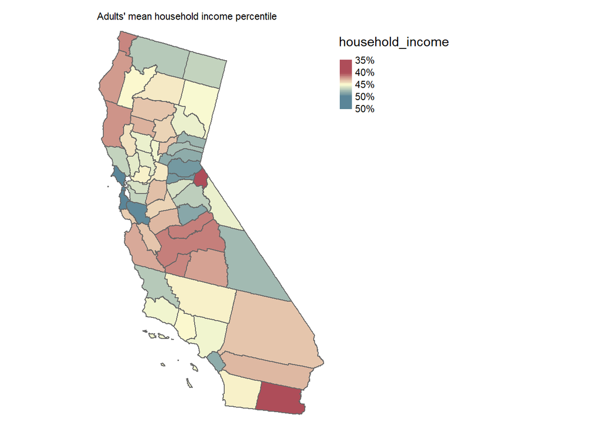

```r
tm_basemap(leaflet::providers$Stamen.TonerLite) +
  tm_shape(my_state_bounds) +
  tm_polygons(
    "household_income",
    breaks = color_breaks(my_state_bounds, "household_income"),
    style = "cont",
    palette = atlas_colors,
    colorNA = atlas_na_color,
    labels = my_format(color_breaks(my_state_bounds, "household_income")),
    legend.format = my_format(color_breaks(my_state_bounds, "household_income")),
    id = "NAME",
    popup.vars = "household_income",
    alpha = .8
  ) +
  tm_layout(
    frame = FALSE,
    main.title = "Adults' mean household income percentile",
    main.title.size = .7,
    legend.outside = TRUE,
    legend.outside.position = "right"
  ) +
  tmap_mode("plot")
```

```r
tm_basemap(leaflet::providers$Stamen.TonerLite) +
  tm_shape(my_state_bounds) +
  tm_polygons(
    "educated_bachelors",
    breaks = color_breaks(my_state_bounds, "educated_bachelors"),
    style = "cont",
    palette = atlas_colors,
    colorNA = atlas_na_color,
    labels = my_format(color_breaks(my_state_bounds, "educated_bachelors")),
    legend.format = my_format(color_breaks(my_state_bounds, "educated_bachelors")),
    id = "NAME",
    popup.vars = "educated_bachelors",
    alpha = .8
  ) +
  tm_layout(
    frame = FALSE,
    main.title = "% of adults with a bachelors degree",
    main.title.size = .7,
    legend.outside = TRUE,
    legend.outside.position = "right"
  ) +
  tmap_mode("view")
```

```
## tmap mode set to interactive viewing
```

[interactive chart not shown]

```
## tmap mode set to plotting
```

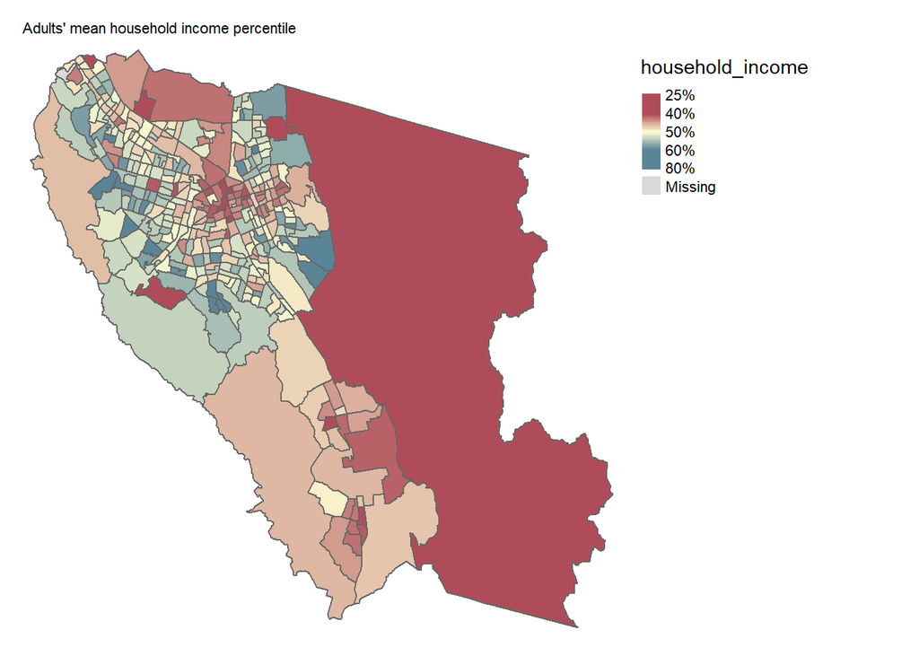

```r
tm_basemap(leaflet::providers$Stamen.TonerLite) +
  tm_shape(my_county_bounds) +
  tm_polygons(
    "household_income",
    breaks = color_breaks(my_county_bounds, "household_income"),
    style = "cont",
    palette = atlas_colors,
    colorNA = atlas_na_color,
    labels = my_format(color_breaks(my_county_bounds, "household_income")),
    legend.format = my_format(color_breaks(my_county_bounds, "household_income")),
    id = "NAME",
    popup.vars = "household_income",
    alpha = .8
  ) +
  tm_layout(
    frame = FALSE,
    main.title = "Adults' mean household income percentile",
    main.title.size = .7,
    legend.outside = TRUE,
    legend.outside.position = "right"
  ) +
  tmap_mode("plot")
```

```r
tm_basemap(leaflet::providers$Stamen.TonerLite) +
  tm_shape(my_county_bounds) +
  tm_polygons(
    "teen_birth",
    breaks = color_breaks(my_county_bounds, "teen_birth"),
    style = "cont",
    palette = rev(atlas_colors),
    colorNA = atlas_na_color,
    labels = my_format(color_breaks(my_county_bounds, "teen_birth")),
    legend.format = my_format(color_breaks(my_county_bounds, "teen_birth")),
    id = "NAME",
    popup.vars = "teen_birth",
    alpha = .8
  ) +
  tm_layout(
    frame = FALSE,
    main.title = "% of adults with a bachelors degree",
    main.title.size = .7,
    legend.outside = TRUE,
    legend.outside.position = "right"
  ) +
  tmap_mode("view")
```

```
## tmap mode set to interactive viewing
```

[interactive chart not shown]

```r
if (SAVE_ANSWERS) {
  ls(pattern = "^q[1-9][0-9]*(\\.[1-9][0-9]*)*$") %>%
    str_sort(numeric = TRUE) %>%
    set_names() %>%
    map(get) %>%
    discard(is.ggplot) %>%
    write_rds(file_answers)
}
```